# DA410_Exam1_MattGraham

R portion of Exam 1

```r
library(nnspat)  # used for dist2full()
library("dplyr")  # used to select numeric datatypes
library("ggplot2")
library(reshape)  # used for melting matricies
library(klaR)
library(ggvis)
library(class)
library(gmodels)
library(MASS)
library(readxl)
library(psych)
```

## Problem 1

```r
c1 <- c(2, -2, 1)
c2 <- c(1, 2, 2)
c3 <- c(2, 1, -2)

p.1.mat <- t(cbind(c1, c2, c3))
p.1.mat
```

```
##    [,1] [,2] [,3]
## c1    2   -2    1
## c2    1    2    2
## c3    2    1   -2
```

## Problem 2

```r
p.2.a <- cbind(c(3, -1), c(2, 1))
p.2.b <- cbind(c(0, 6), c(2, 2))
```

### A

```r
p.2.a %*% p.2.b
```

```
##      [,1] [,2]
## [1,]   12   10
## [2,]    6    0
```

### B

```r
p.2.b %*% p.2.a
```

```
##      [,1] [,2]
## [1,]   -2    2
## [2,]   16   14
```

## Problem 3

```r
p.3.a <- cbind(c(3, 8), c(4, 5), c(2, 7))
p.3.b <- cbind(c(4, -5), c(3, 9), c(-2, 6))
```

### A

```r
a.pl.b <- p.3.a + p.3.b
a.pl.b
```

```
##      [,1] [,2] [,3]
## [1,]    7    7    0
## [2,]    3   14   13
```

```r
a.mi.b <- p.3.a - p.3.b
a.mi.b
```

```
##      [,1] [,2] [,3]
## [1,]   -1    1    4
## [2,]   13   -4    1
```

### B

```r
p.3.a.t <- t(p.3.a)
a.tr.a <- p.3.a %*% p.3.a.t
a.tr.a
```

```
##      [,1] [,2]
## [1,]   29   58
## [2,]   58  138
```

```r
a.a.tr <- p.3.a.t %*% p.3.a
a.a.tr
```

```
##      [,1] [,2] [,3]
## [1,]   73   52   62
## [2,]   52   41   43
## [3,]   62   43   53
```

### C

```r
t(p.3.a + p.3.b)
```

```
##      [,1] [,2]
## [1,]    7    3
## [2,]    7   14
## [3,]    0   13
```

```r
p.3.a.t + t(p.3.b)
```

```
##      [,1] [,2]
## [1,]    7    3
## [2,]    7   14
## [3,]    0   13
```

## Problem 4

Get Reagent data

```r
reagents <- read.table("C:/mattgraham93.github.io/school/22_3_DA410/data/T6_19_REAGENT.DAT", header=FALSE)
colnames(reagents) <- c("Reagent", 'Subject', 'w_bc', 'r_bc','hemo')
regeants <- reagents[-2]  # remove subject id
reagents
```

| Reagent | Subject | w_bc | r_bc | hemo |
| --- | --- | --- | --- | --- |
| 1 | 1 | 8.0 | 3.96 | 12.5 |
| 1 | 2 | 4.0 | 5.37 | 16.9 |
| 1 | 3 | 6.3 | 5.47 | 17.1 |
| 1 | 4 | 9.4 | 5.16 | 16.2 |
| 1 | 5 | 8.2 | 5.16 | 17.0 |
| 1 | 6 | 11.0 | 4.67 | 14.3 |
| 1 | 7 | 6.8 | 5.20 | 16.2 |
| 1 | 8 | 9.0 | 4.65 | 14.7 |
| 1 | 9 | 6.1 | 5.22 | 16.3 |
| 1 | 10 | 6.4 | 5.13 | 15.9 |

[output cut: 70 more lines]

#### Preparing the matricies

```r
reagents$Reagent <- as.factor(reagents$Reagent)

reagent1 <- reagents[reagents$Reagent==1, 3:5]
reagent2 <- reagents[reagents$Reagent==2, 3:5]
reagent3 <- reagents[reagents$Reagent==3, 3:5]
reagent4 <- reagents[reagents$Reagent==4, 3:5]


# calculating within matricies

reagent1.bar <- colMeans(reagent1)
reagent2.bar <- colMeans(reagent2)
reagent3.bar <- colMeans(reagent3)
reagent4.bar <- colMeans(reagent4)

reagent.bar <- (reagent1.bar + reagent2.bar + reagent3.bar + reagent4.bar) / 4

reagent1.bar.diff <- reagent1.bar - reagent.bar
reagent2.bar.diff <- reagent2.bar - reagent.bar
reagent3.bar.diff <- reagent3.bar - reagent.bar
reagent4.bar.diff <- reagent4.bar - reagent.bar


H <- 12 * unname(reagent1.bar.diff %*% t(reagent1.bar.diff)
                 + reagent2.bar.diff %*% t(reagent2.bar.diff)
                 + reagent3.bar.diff %*% t(reagent3.bar.diff)
                 + reagent4.bar.diff %*% t(reagent4.bar.diff)
                 )

"compute.within.matrix" <- function(data, mean) {
  ret <- matrix(as.numeric(0), nrow=3, ncol=3)

  for (i in 1:12) {
      diff <- as.numeric(data[i,] - mean)
      ret <- ret + diff %*% t(diff)
  }
  return(ret)
}

E <- compute.within.matrix(reagent1, reagent1.bar) + compute.within.matrix(reagent3, reagent2.bar) +
compute.within.matrix(reagent3, reagent3.bar) + compute.within.matrix(reagent4, reagent4.bar)

E
```

```
##           [,1]       [,2]      [,3]
## [1,] 152.16620 -12.936790 -29.66550
## [2,] -12.93679   9.178373  29.16563
## [3,] -29.66550  29.165630 101.56870
```

### A - Compare reagents using all four MANOVA tests

#### Wilks’ test

```r
# Wilks' Test
lambda <- det(E) / det(E + H)
lambda
```

```
## [1] 0.6895358
```

Hypothesis: Wilks’ looks at all discriminate functions versus just one combination. Lambda becomes smaller as the between groups variance increases We are looking to determine whether or not there is a significant variance across each of our reagents.

*Ho:* There are no significant differences between reagents

*Ha:* There exists at least one differences between reagents

Conclusion: When testing for significance at 0.05, we can conclude there is not enough evidence to conclude there are significant differences between our 4 reagents.

#### Roy’s Test

```r
lambda.1 <- eigen(solve(E) %*% H)$values[1]
theta <- lambda.1 / (1 + lambda.1)
theta
```

```
## [1] 0.3087024
```

Hypothesis: Roy is best used when variables are strongly interrelated on a single dimension, most affected by assumptions. We are looking to determine whether or not there is a significant variance across each of our reagents.

*Ho:* There are no significant differences between reagents

*Ha:* There exists at least one differences between reagents

Conclusion: When testing for significance at 0.05, we can conclude there is not enough evidence to conclude there are significant differences between our 4 reagents.

#### Pillai test

```r
V.s <- tr(solve(E+H) %*% H)
V.s
```

```
## [1] 0.3112515
```

Hypothesis: Like Roy, considers all discriminant functions. Has wider range of accuracy due to addition of actual values. Best used on small, unequal groups. Or covariance exists

*Ho:* There are no significant differences between reagents

*Ha:* There exists at least one differences between reagents

Conclusion: When testing for significance at 0.05, we can conclude there is not enough evidence to conclude there are significant differences between our 4 reagents.

#### Lawley-Hotelling Test

```r
U.s <- tr(solve(E) %*% H)
U.s
```

```
## [1] 0.4491095
```

Hypothesis: Like Roy, considers all discriminant functions. Narrower accuracy band, resulting in greater risk of error

*Ho:* There are no significant differences between reagents

*Ha:* There exists at least one differences between reagents

Conclusion: When testing for significance at 0.05, we can conclude there is not enough evidence to conclude there are significant differences between our 4 reagents.

### B - Multivariate associations

```r
s = 3

eta.sq.lam <- 1 - lambda
eta.sq.theta <- theta
a.lam <- 1 - lambda ** (1/s)
a.p <- V.s / s
a.lh <- (U.s / s) / (1 + (U.s / s))

mult.df <- data.frame(
  cbind(
    c("eta.sq.lam", "eta.sq.theta", "a.lam", "a.p", "a.lh"),
    c(eta.sq.lam, eta.sq.theta, a.lam, a.p, a.lh))
)
mult.df
```

| X1 | X2 |
| --- | --- |
| eta.sq.lam | 0.310464195404419 |
| eta.sq.theta | 0.308702431872756 |
| a.lam | 0.116542611085165 |
| a.p | 0.10375050158492 |
| a.lh | 0.130210270962564 |

## Problem 5

Get student score data

```r
student <- c(1, 2, 3, 4, 5)
math <- c(90, 90, 60, 60, 30)
english <- c(60, 90, 60, 60, 30)
art <- c(90, 30, 60, 90, 30)

scores <- data.frame(cbind(student, math, english, art))
scores
```

| student | math | english | art |
| --- | --- | --- | --- |
| 1 | 90 | 60 | 90 |
| 2 | 90 | 90 | 30 |
| 3 | 60 | 60 | 60 |
| 4 | 60 | 60 | 90 |
| 5 | 30 | 30 | 30 |

### A - Finding covariance

```r
S <- cov(scores[, -1])
S
```

```
##         math english art
## math     630     450 225
## english  450     450   0
## art      225       0 900
```

### B - Finding correlation

```r
R <- cor(scores[, -1])
R
```

```
##              math   english       art
## math    1.0000000 0.8451543 0.2988072
## english 0.8451543 1.0000000 0.0000000
## art     0.2988072 0.0000000 1.0000000
```

Analysis: We can see there is a relatively strong correlation between math and english scores. There is no correlation between art and english, with moderate correlation between art and math.

### C - Vector calculations

```r
### z = -2(math) + 3(engliths) + art

lin_comb <- matrix(c(-2, 3, 1), nrow=1)
a <- t(lin_comb)

sub.means <- matrix(colMeans(scores[, -1]))
z.bar <- lin_comb %*% sub.means
z.s2 <- lin_comb %*% S %*% a

data.frame(z.bar, z.s2)
```

| z.bar | z.s2 |
| --- | --- |
| 108 | 1170 |

## Problem 6

Get Beetles data

```r
beetles <- read.table("C:/mattgraham93.github.io/school/22_3_DA410/data/T5_5_FBEETLES.DAT", header=FALSE)
colnames(beetles) <- c("Experiment", 'Species', 'post_dist', 'l_elytra','len_sec_an', 'len_thi_an')

oleracea <- beetles[beetles$Species==1, -c(1:2)]  # we assume that species 1 = oleracea
carduorum <- beetles[beetles$Species==2, -c(1:2)] # we assume that species 2 = carduorum

beetles
```

| Experiment | Species | post_dist | l_elytra | len_sec_an | len_thi_an |
| --- | --- | --- | --- | --- | --- |
| 1 | 1 | 189 | 245 | 137 | 163 |
| 2 | 1 | 192 | 260 | 132 | 217 |
| 3 | 1 | 217 | 276 | 141 | 192 |
| 4 | 1 | 221 | 299 | 142 | 213 |
| 5 | 1 | 171 | 239 | 128 | 158 |
| 6 | 1 | 192 | 262 | 147 | 173 |
| 7 | 1 | 213 | 278 | 136 | 201 |
| 8 | 1 | 192 | 255 | 128 | 185 |
| 9 | 1 | 170 | 244 | 128 | 192 |
| 10 | 1 | 201 | 276 | 146 | 186 |

[output cut: 29 more lines]

### A

```r
beetles.lda <- lda(Species ~ post_dist + l_elytra + len_sec_an + len_thi_an, data=beetles, prior=c(0.5, 0.5))
beetles.lda
```

```
## Call:
## lda(Species ~ post_dist + l_elytra + len_sec_an + len_thi_an,
##     data = beetles, prior = c(0.5, 0.5))
##
## Prior probabilities of groups:
##   1   2
## 0.5 0.5
##
## Group means:
##   post_dist l_elytra len_sec_an len_thi_an
## 1  194.4737 267.0526   137.3684   185.9474
## 2  179.5500 290.8000   157.2000   209.2500
##
## Coefficients of linear discriminants:
##                    LD1
## post_dist  -0.09327642
## l_elytra    0.03522706
## len_sec_an  0.02875538
## len_thi_an  0.03872998
```

We can see above that our discriminants are all positive exist for post_dist. Which means that is our primary differentiations between our 2 classifications. We will note this in the plot below.

species = -.0932 * post_dist + .0352 * l_elytra + .0288 * len_sec_an + .0387 * len_thi_an

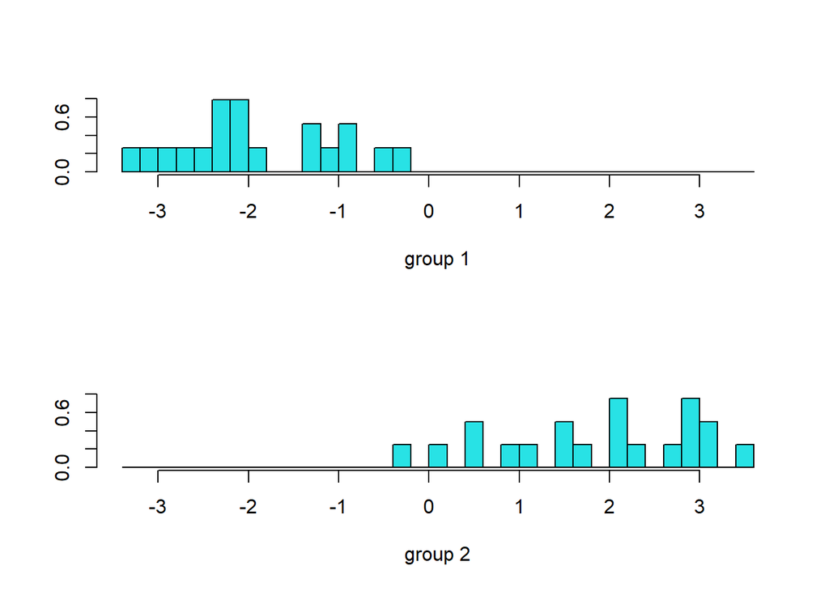

```r
plot(beetles.lda)
```

### B

Getting covariance matricies for subsets

```r
cov.oleracea <- cov(oleracea)
cov.carduorum <- cov(carduorum)
```

```r
as.data.frame(cov.oleracea)
```

|  | post_dist | l_elytra | len_sec_an | len_thi_an |
| --- | --- | --- | --- | --- |
| post_dist | 187.59649 | 176.86257 | 48.37135 | 113.58187 |
| l_elytra | 176.86257 | 345.38596 | 75.97953 | 118.78070 |
| len_sec_an | 48.37135 | 75.97953 | 66.35673 | 16.24269 |
| len_thi_an | 113.58187 | 118.78070 | 16.24269 | 239.94152 |

```r
as.data.frame(cov.carduorum)
```

|  | post_dist | l_elytra | len_sec_an | len_thi_an |
| --- | --- | --- | --- | --- |
| post_dist | 101.83947 | 128.06316 | 36.98947 | 32.59211 |
| l_elytra | 128.06316 | 389.01053 | 165.35789 | 94.36842 |
| len_sec_an | 36.98947 | 165.35789 | 167.53684 | 66.52632 |
| len_thi_an | 32.59211 | 94.36842 | 66.52632 | 177.88158 |

Calculating pooled variance:

```r
oleracea.n <- nrow(oleracea)
oleracea.df <- oleracea.n - 1

carduorum.n <- nrow(carduorum)
carduorum.df <- carduorum.n - 1

beetles.n <- nrow(beetles)

beetles.pooled.var <- ( (oleracea.df*cov.oleracea) %*% (carduorum.df*cov.carduorum)) / beetles.n
as.data.frame(beetles.pooled.var)
```

|  | post_dist | l_elytra | len_sec_an | len_thi_an |
| --- | --- | --- | --- | --- |
| post_dist | 414305.9 | 978143.9 | 454639.8 | 405370.8 |
| l_elytra | 604415.4 | 1585313.1 | 739121.3 | 565978.3 |
| len_sec_an | 154690.8 | 423175.3 | 232830.2 | 140749.1 |
| len_thi_an | 308673.0 | 754867.3 | 372923.2 | 514515.0 |

```r
diag(beetles.pooled.var)
```

```
##  post_dist   l_elytra len_sec_an len_thi_an
##   414305.9  1585313.1   232830.2   514515.0
```

### C - T tests

```r
t.test(beetles$post_dist~beetles$Species)
```

```
##
##  Welch Two Sample t-test
##
## data:  beetles$post_dist by beetles$Species
## t = 3.8577, df = 33.031, p-value = 0.0005024
## alternative hypothesis: true difference in means between group 1 and group 2 is not equal to 0
## 95 percent confidence interval:
##   7.053392 22.793977
## sample estimates:
## mean in group 1 mean in group 2
##        194.4737        179.5500
```

```r
t.test(beetles$l_elytra~beetles$Species)
```

```
##
##  Welch Two Sample t-test
##
## data:  beetles$l_elytra by beetles$Species
## t = -3.8713, df = 36.998, p-value = 0.0004251
## alternative hypothesis: true difference in means between group 1 and group 2 is not equal to 0
## 95 percent confidence interval:
##  -36.17651 -11.31823
## sample estimates:
## mean in group 1 mean in group 2
##        267.0526        290.8000
```

```r
t.test(beetles$len_sec_an~beetles$Species)
```

```
##
##  Welch Two Sample t-test
##
## data:  beetles$len_sec_an by beetles$Species
## t = -5.7563, df = 32.232, p-value = 2.146e-06
## alternative hypothesis: true difference in means between group 1 and group 2 is not equal to 0
## 95 percent confidence interval:
##  -26.84721 -12.81594
## sample estimates:
## mean in group 1 mean in group 2
##        137.3684        157.2000
```

```r
t.test(beetles$len_thi_an~beetles$Species)
```

```
##
##  Welch Two Sample t-test
##
## data:  beetles$len_thi_an by beetles$Species
## t = -5.0229, df = 35.569, p-value = 1.441e-05
## alternative hypothesis: true difference in means between group 1 and group 2 is not equal to 0
## 95 percent confidence interval:
##  -32.71542 -13.88985
## sample estimates:
## mean in group 1 mean in group 2
##        185.9474        209.2500
```

Above, we can conclude that there are significant differences between all variables as it pertains to both beetles species.

## Problem 7

Get Glucose data

```r
glucose <- read_excel("C:/mattgraham93.github.io/school/22_3_DA410/data/gluecose.xlsx")

fasting <- subset(glucose, SugarIntakeFlag == "Before")[-1]
post.cons <- subset(glucose, SugarIntakeFlag == "After")[-1]

glucose <- cbind(fasting, post.cons)
colnames(glucose) <- c('b_time1', 'b_time2', 'b_time3', 'a_time1', 'a_time2', 'a_time3')  # b = before, a = after

glucose
```

| b_time1 | b_time2 | b_time3 | a_time1 | a_time2 | a_time3 |
| --- | --- | --- | --- | --- | --- |
| 62 | 75 | 68 | 116 | 130 | 91 |
| 74 | 64 | 70 | 109 | 101 | 103 |
| 64 | 71 | 66 | 77 | 102 | 130 |
| 73 | 70 | 64 | 115 | 110 | 109 |
| 68 | 67 | 75 | 76 | 85 | 119 |
| 69 | 82 | 74 | 72 | 133 | 127 |
| 60 | 67 | 61 | 130 | 134 | 121 |
| 70 | 74 | 78 | 150 | 158 | 100 |
| 66 | 74 | 78 | 150 | 131 | 142 |
| 83 | 70 | 74 | 99 | 98 | 105 |

[output cut: 20 more lines]

### Getting mean vector and covariance matrix

Mean matrix

```r
x.bar <- mean(colMeans(fasting))
y.bar <- mean(colMeans(post.cons))

cbind.data.frame(x.bar, y.bar)
```

| x.bar | y.bar |
| --- | --- |
| 72.74444 | 106.4667 |

```r
my.S <- round(var(glucose), digits=2)
my.S
```

```
##         b_time1 b_time2 b_time3 a_time1 a_time2 a_time3
## b_time1   77.61    0.99   23.73  100.08    4.87   34.32
## b_time2    0.99   36.20   15.22  -46.46   30.37  -32.08
## b_time3   23.73   15.22   57.46   13.41   -6.42    1.48
## a_time1  100.08  -46.46   13.41  959.50  299.36  232.64
## a_time2    4.87   30.37   -6.42  299.36  500.19   61.81
## a_time3   34.32  -32.08    1.48  232.64   61.81  527.02
```

Finding correlation matrix

```r
my.R <- round(cor(glucose), digits=2)
my.R
```

```
##         b_time1 b_time2 b_time3 a_time1 a_time2 a_time3
## b_time1    1.00    0.02    0.36    0.37    0.02    0.17
## b_time2    0.02    1.00    0.33   -0.25    0.23   -0.23
## b_time3    0.36    0.33    1.00    0.06   -0.04    0.01
## a_time1    0.37   -0.25    0.06    1.00    0.43    0.33
## a_time2    0.02    0.23   -0.04    0.43    1.00    0.12
## a_time3    0.17   -0.23    0.01    0.33    0.12    1.00
```

## Problem 8

Get Goods data

```r
goods <- read.table("C:/mattgraham93.github.io/school/22_3_DA410/data/T5_8_GOODS.DAT", header=FALSE)
## GoodType = 1 = Consumer; GoodType = 2 = Producer
colnames(goods) <- c("Item", 'GoodType', 'l_cycle', 'pct_hir_price','cyc_amp', 'chng_rt')

consumer.goods <- goods[goods$GoodType==1,]
producer.goods <- goods[goods$GoodType==2,]

goods
```

| Item | GoodType | l_cycle | pct_hir_price | cyc_amp | chng_rt |
| --- | --- | --- | --- | --- | --- |
| 1 | 1 | 72.0 | 50 | 8.0 | 0.5 |
| 2 | 1 | 66.5 | 48 | 15.0 | 1.0 |
| 3 | 1 | 54.0 | 57 | 14.0 | 1.0 |
| 4 | 1 | 67.0 | 60 | 15.0 | 0.9 |
| 5 | 1 | 44.0 | 57 | 14.0 | 0.3 |
| 6 | 1 | 41.0 | 52 | 18.0 | 1.9 |
| 7 | 1 | 34.5 | 50 | 4.0 | 0.5 |
| 8 | 1 | 34.5 | 46 | 8.5 | 1.0 |
| 9 | 1 | 24.0 | 54 | 3.0 | 1.2 |
| 1 | 2 | 57.0 | 57 | 12.5 | 0.9 |

[output cut: 9 more lines]

### A

Hotelling’s T^2 test

```r
goods.manova <- manova(cbind(l_cycle, pct_hir_price, cyc_amp, chng_rt) ~GoodType, data=goods[, 2:6])

summary(goods.manova, test="Hotelling")
```

```
##           Df Hotelling-Lawley approx F num Df den Df  Pr(>F)
## GoodType   1            1.086   3.8011      4     14 0.02702 *
## Residuals 17
## ---
## Signif. codes:  0 '***' 0.001 '**' 0.01 '*' 0.05 '.' 0.1 ' ' 1
```

*Ho:* The good types have equal variation between all variables

*Ha:* At least one variable is unequal between the 2 good types

Conclusion: At alpha = 0.05, we can say there is enough evidence to conclude at least one variable has significant differences between the two good types. We will learn more about this below.

### B

Assumption check

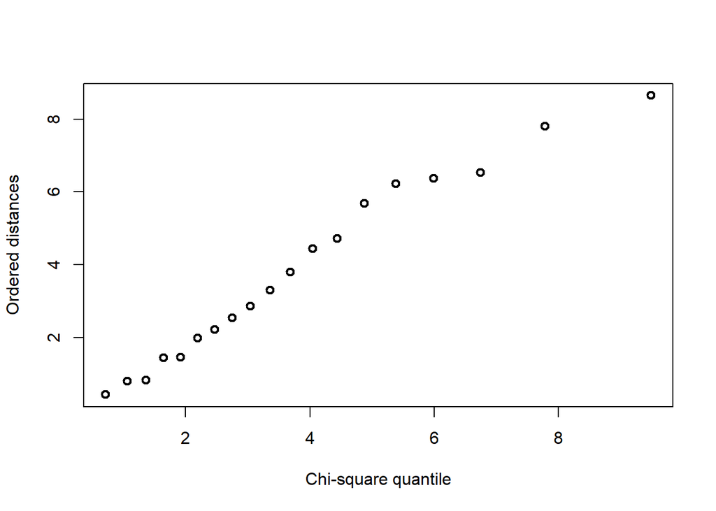

```r
chisplot <- function(x) {
    if (!is.matrix(x)) stop("x is not a matrix")
    ### determine dimensions
    n <- nrow(x)
    p <- ncol(x)
    xbar <- apply(x, 2, mean)
    S <- var(x)
    S <- solve(S)
    index <- (1:n)/(n+1)
    xcent <- t(t(x) - xbar)
    di <- apply(xcent, 1, function(x,S) x %*% S %*% x,S)
    quant <- qchisq(index,p)
    plot(quant, sort(di), ylab = "Ordered distances",
         xlab = "Chi-square quantile", lwd=2,pch=1)
}

chisplot(residuals(goods.manova))
```

```r
my.n <- nrow(goods)  # number of individuals

# Sample mean vectors for goods:
as.data.frame(
  goods %>%
    group_by(GoodType) %>%
    summarise_at(vars('l_cycle', 'pct_hir_price','cyc_amp', 'chng_rt'), mean)
)
```

| GoodType | l_cycle | pct_hir_price | cyc_amp | chng_rt |
| --- | --- | --- | --- | --- |
| 1 | 48.61111 | 52.66667 | 11.05556 | 0.9222222 |
| 2 | 90.30000 | 50.50000 | 17.40000 | 1.0700000 |

Overall, we can notice there is some increasing variation the more extreme our values become. This makes sense due to the consistency within our data. It is safe to say that our model checks all the necessary requirements to be utilized for predictions.

As hinted to above, our primary variable with significant differences are l_cycle.